# Risk Factor Analysis

## Outcome Variable

**Outcome Variable:** wast_rec90d

## Predictor Variables

**Intervention Variable:** hfoodsec

**Adjustment Set:**

- arm
- sex
- W_mage
- meducyrs
- feducyrs
- hhwealth_quart
- vagbrth
- W_nrooms
- W_nchldlt5
- brthmon
- W_parity
- impfloor
- impsan
- safeh20
- delta_W_mage
- delta_meducyrs
- delta_feducyrs
- delta_hhwealth_quart
- delta_vagbrth
- delta_W_nrooms
- delta_W_nchldlt5
- delta_brthmon
- delta_W_parity
- delta_impfloor
- delta_impsan
- delta_safeh20

## Stratifying Variables

The analysis was stratified on these variable(s):

- agecat
- studyid
- country

## Data Summary

| agecat | studyid | country | hfoodsec | wast_rec90d | n_cell | n |
| --- | --- | --- | --- | --- | --- | --- |
| 0-24 months | ki0047075b-MAL-ED | BANGLADESH | Food Secure | 0 | 31 | 100 |
| 0-24 months | ki0047075b-MAL-ED | BANGLADESH | Food Secure | 1 | 48 | 100 |
| 0-24 months | ki0047075b-MAL-ED | BANGLADESH | Mildly Food Insecure | 0 | 1 | 100 |
| 0-24 months | ki0047075b-MAL-ED | BANGLADESH | Mildly Food Insecure | 1 | 2 | 100 |
| 0-24 months | ki0047075b-MAL-ED | BANGLADESH | Food Insecure | 0 | 7 | 100 |
| 0-24 months | ki0047075b-MAL-ED | BANGLADESH | Food Insecure | 1 | 11 | 100 |
| 0-24 months | ki0047075b-MAL-ED | BRAZIL | Food Secure | 0 | 0 | 14 |
| 0-24 months | ki0047075b-MAL-ED | BRAZIL | Food Secure | 1 | 0 | 14 |
| 0-24 months | ki0047075b-MAL-ED | BRAZIL | Mildly Food Insecure | 0 | 0 | 14 |
| 0-24 months | ki0047075b-MAL-ED | BRAZIL | Mildly Food Insecure | 1 | 0 | 14 |
| 0-24 months | ki0047075b-MAL-ED | BRAZIL | Food Insecure | 0 | 3 | 14 |
| 0-24 months | ki0047075b-MAL-ED | BRAZIL | Food Insecure | 1 | 11 | 14 |
| 0-24 months | ki0047075b-MAL-ED | INDIA | Food Secure | 0 | 54 | 159 |
| 0-24 months | ki0047075b-MAL-ED | INDIA | Food Secure | 1 | 88 | 159 |
| 0-24 months | ki0047075b-MAL-ED | INDIA | Mildly Food Insecure | 0 | 3 | 159 |
| 0-24 months | ki0047075b-MAL-ED | INDIA | Mildly Food Insecure | 1 | 2 | 159 |
| 0-24 months | ki0047075b-MAL-ED | INDIA | Food Insecure | 0 | 6 | 159 |
| 0-24 months | ki0047075b-MAL-ED | INDIA | Food Insecure | 1 | 6 | 159 |
| 0-24 months | ki0047075b-MAL-ED | NEPAL | Food Secure | 0 | 9 | 62 |
| 0-24 months | ki0047075b-MAL-ED | NEPAL | Food Secure | 1 | 35 | 62 |
| 0-24 months | ki0047075b-MAL-ED | NEPAL | Mildly Food Insecure | 0 | 1 | 62 |
| 0-24 months | ki0047075b-MAL-ED | NEPAL | Mildly Food Insecure | 1 | 5 | 62 |
| 0-24 months | ki0047075b-MAL-ED | NEPAL | Food Insecure | 0 | 1 | 62 |
| 0-24 months | ki0047075b-MAL-ED | NEPAL | Food Insecure | 1 | 11 | 62 |
| 0-24 months | ki0047075b-MAL-ED | PERU | Food Secure | 0 | 2 | 18 |
| 0-24 months | ki0047075b-MAL-ED | PERU | Food Secure | 1 | 6 | 18 |
| 0-24 months | ki0047075b-MAL-ED | PERU | Mildly Food Insecure | 0 | 0 | 18 |
| 0-24 months | ki0047075b-MAL-ED | PERU | Mildly Food Insecure | 1 | 0 | 18 |
| 0-24 months | ki0047075b-MAL-ED | PERU | Food Insecure | 0 | 2 | 18 |
| 0-24 months | ki0047075b-MAL-ED | PERU | Food Insecure | 1 | 8 | 18 |

[output cut: 168 more lines]

The following strata were considered:

- agecat: 0-24 months, studyid: ki0047075b-MAL-ED, country: BANGLADESH
- agecat: 0-24 months, studyid: ki0047075b-MAL-ED, country: BRAZIL
- agecat: 0-24 months, studyid: ki0047075b-MAL-ED, country: INDIA
- agecat: 0-24 months, studyid: ki0047075b-MAL-ED, country: NEPAL
- agecat: 0-24 months, studyid: ki0047075b-MAL-ED, country: PERU
- agecat: 0-24 months, studyid: ki0047075b-MAL-ED, country: SOUTH AFRICA
- agecat: 0-24 months, studyid: ki1017093-NIH-Birth, country: BANGLADESH
- agecat: 0-24 months, studyid: ki1017093c-NIH-Crypto, country: BANGLADESH
- agecat: 0-24 months, studyid: ki1113344-GMS-Nepal, country: NEPAL
- agecat: 0-24 months, studyid: kiGH5241-JiVitA-3, country: BANGLADESH
- agecat: 0-24 months, studyid: kiGH5241-JiVitA-4, country: BANGLADESH
- agecat: 0-6 months, studyid: ki0047075b-MAL-ED, country: BANGLADESH
- agecat: 0-6 months, studyid: ki0047075b-MAL-ED, country: BRAZIL
- agecat: 0-6 months, studyid: ki0047075b-MAL-ED, country: INDIA
- agecat: 0-6 months, studyid: ki0047075b-MAL-ED, country: NEPAL
- agecat: 0-6 months, studyid: ki0047075b-MAL-ED, country: PERU
- agecat: 0-6 months, studyid: ki0047075b-MAL-ED, country: SOUTH AFRICA
- agecat: 0-6 months, studyid: ki1017093-NIH-Birth, country: BANGLADESH
- agecat: 0-6 months, studyid: ki1017093c-NIH-Crypto, country: BANGLADESH
- agecat: 0-6 months, studyid: ki1113344-GMS-Nepal, country: NEPAL
- agecat: 0-6 months, studyid: kiGH5241-JiVitA-3, country: BANGLADESH
- agecat: 0-6 months, studyid: kiGH5241-JiVitA-4, country: BANGLADESH
- agecat: 6-24 months, studyid: ki0047075b-MAL-ED, country: BANGLADESH
- agecat: 6-24 months, studyid: ki0047075b-MAL-ED, country: BRAZIL
- agecat: 6-24 months, studyid: ki0047075b-MAL-ED, country: INDIA
- agecat: 6-24 months, studyid: ki0047075b-MAL-ED, country: NEPAL
- agecat: 6-24 months, studyid: ki0047075b-MAL-ED, country: PERU
- agecat: 6-24 months, studyid: ki0047075b-MAL-ED, country: SOUTH AFRICA
- agecat: 6-24 months, studyid: ki1017093-NIH-Birth, country: BANGLADESH
- agecat: 6-24 months, studyid: ki1017093c-NIH-Crypto, country: BANGLADESH
- agecat: 6-24 months, studyid: ki1113344-GMS-Nepal, country: NEPAL
- agecat: 6-24 months, studyid: kiGH5241-JiVitA-3, country: BANGLADESH
- agecat: 6-24 months, studyid: kiGH5241-JiVitA-4, country: BANGLADESH

### Dropped Strata

- agecat: 0-24 months, studyid: ki0047075b-MAL-ED, country: BANGLADESH
- agecat: 0-24 months, studyid: ki0047075b-MAL-ED, country: BRAZIL
- agecat: 0-24 months, studyid: ki0047075b-MAL-ED, country: INDIA
- agecat: 0-24 months, studyid: ki0047075b-MAL-ED, country: NEPAL
- agecat: 0-24 months, studyid: ki0047075b-MAL-ED, country: PERU
- agecat: 0-24 months, studyid: ki0047075b-MAL-ED, country: SOUTH AFRICA
- agecat: 0-6 months, studyid: ki0047075b-MAL-ED, country: BANGLADESH
- agecat: 0-6 months, studyid: ki0047075b-MAL-ED, country: BRAZIL
- agecat: 0-6 months, studyid: ki0047075b-MAL-ED, country: INDIA
- agecat: 0-6 months, studyid: ki0047075b-MAL-ED, country: NEPAL
- agecat: 0-6 months, studyid: ki0047075b-MAL-ED, country: PERU
- agecat: 0-6 months, studyid: ki0047075b-MAL-ED, country: SOUTH AFRICA
- agecat: 0-6 months, studyid: ki1017093c-NIH-Crypto, country: BANGLADESH
- agecat: 6-24 months, studyid: ki0047075b-MAL-ED, country: BANGLADESH
- agecat: 6-24 months, studyid: ki0047075b-MAL-ED, country: BRAZIL
- agecat: 6-24 months, studyid: ki0047075b-MAL-ED, country: INDIA
- agecat: 6-24 months, studyid: ki0047075b-MAL-ED, country: NEPAL
- agecat: 6-24 months, studyid: ki0047075b-MAL-ED, country: PERU
- agecat: 6-24 months, studyid: ki0047075b-MAL-ED, country: SOUTH AFRICA
- agecat: 6-24 months, studyid: ki1017093-NIH-Birth, country: BANGLADESH
- agecat: 6-24 months, studyid: ki1017093c-NIH-Crypto, country: BANGLADESH
- agecat: 6-24 months, studyid: kiGH5241-JiVitA-3, country: BANGLADESH

## Methods Detail

We’re interested in the causal parameters $E[Y_a]$ for all values of $a \in \mathcal{A}$. These parameters represent the mean outcome if, possibly contrary to fact, we intervened to set all units to have $A=a$. Under the randomization and positivity assumptions, these are identified by the statistical parameters $\psi_a=E_W[E_{Y|A,W}(Y|A=a,W)]$. In addition, we’re interested in the mean of $Y$, $E[Y]$ under no intervention (the observed mean). We will estimate these parameters by using SuperLearner to fit the relevant likelihood factors – $E_{Y|A,W}(Y|A=a,W)$ and $p(A=a|W)$, and then updating our likelihood fit using a joint TMLE.

For unadjusted analyses ($W=\{\}$), initial likelihoods were estimated using Lrnr_glm to estimate the simple $E(Y|A)$ and Lrnr_mean to estimate $p(A)$. For adjusted analyses, a small library containing Lrnr_glmnet, Lrnr_xgboost, and Lrnr_mean was used.

Having estimated these parameters, we will then use the delta method to estimate relative risks and attributable risks relative to a prespecified baseline level of $A$.

# Results Detail

## Results Plots

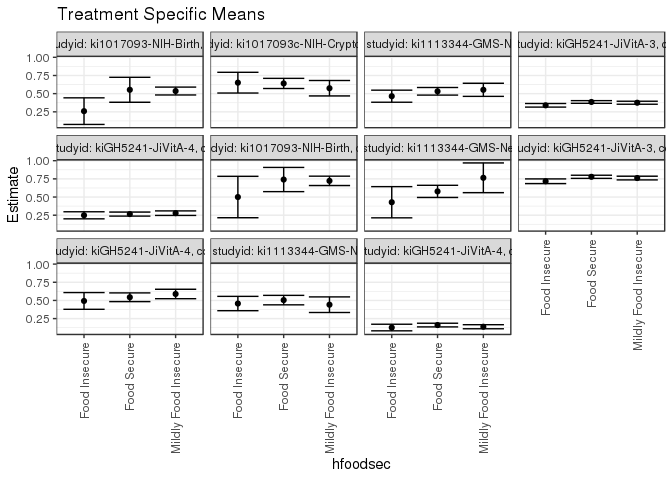

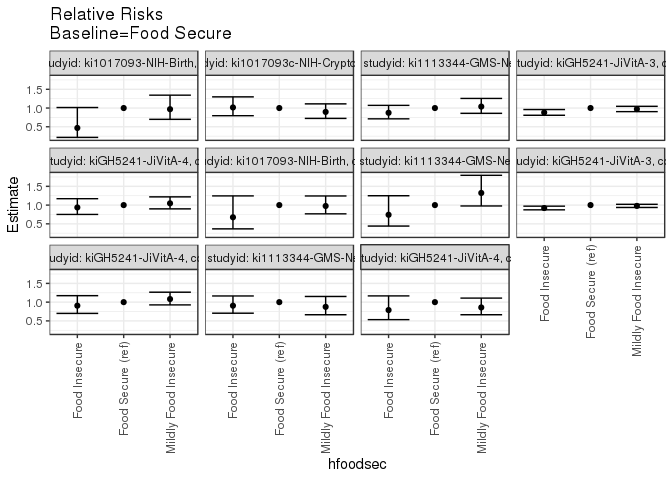

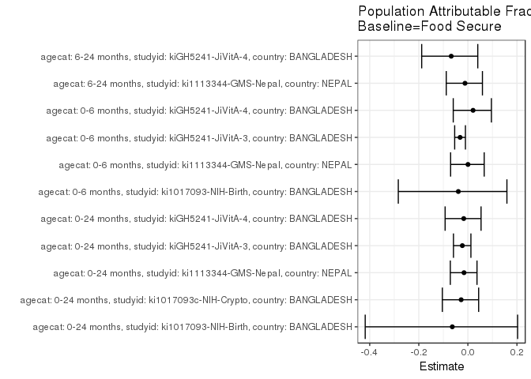

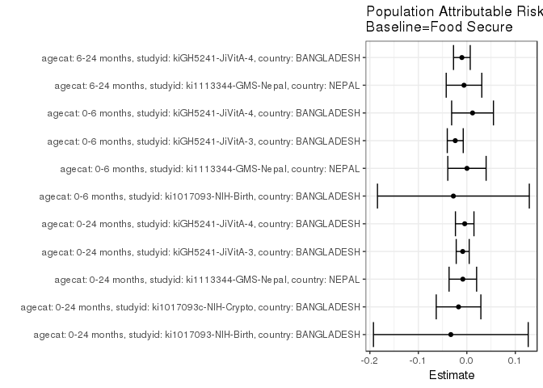

## Results Table

### Parameter: TSM

| agecat | studyid | country | intervention_level | baseline_level | estimate | ci_lower | ci_upper |
| --- | --- | --- | --- | --- | --- | --- | --- |
| 0-24 months | ki1017093-NIH-Birth | BANGLADESH | Food Secure | NA | 0.5531915 | 0.3813656 | 0.7250173 |
| 0-24 months | ki1017093-NIH-Birth | BANGLADESH | Mildly Food Insecure | NA | 0.5360231 | 0.4817521 | 0.5902940 |
| 0-24 months | ki1017093-NIH-Birth | BANGLADESH | Food Insecure | NA | 0.2592593 | 0.0762417 | 0.4422768 |
| 0-24 months | ki1017093c-NIH-Crypto | BANGLADESH | Food Secure | NA | 0.6408840 | 0.5711582 | 0.7106097 |
| 0-24 months | ki1017093c-NIH-Crypto | BANGLADESH | Mildly Food Insecure | NA | 0.5747126 | 0.4686093 | 0.6808160 |
| 0-24 months | ki1017093c-NIH-Crypto | BANGLADESH | Food Insecure | NA | 0.6511628 | 0.5086316 | 0.7936940 |
| 0-24 months | ki1113344-GMS-Nepal | NEPAL | Food Secure | NA | 0.5321345 | 0.4798943 | 0.5843747 |
| 0-24 months | ki1113344-GMS-Nepal | NEPAL | Mildly Food Insecure | NA | 0.5527689 | 0.4625328 | 0.6430049 |
| 0-24 months | ki1113344-GMS-Nepal | NEPAL | Food Insecure | NA | 0.4648573 | 0.3816420 | 0.5480727 |
| 0-24 months | kiGH5241-JiVitA-3 | BANGLADESH | Food Secure | NA | 0.3856541 | 0.3674067 | 0.4039015 |
| 0-24 months | kiGH5241-JiVitA-3 | BANGLADESH | Mildly Food Insecure | NA | 0.3749626 | 0.3542221 | 0.3957030 |
| 0-24 months | kiGH5241-JiVitA-3 | BANGLADESH | Food Insecure | NA | 0.3394731 | 0.3146658 | 0.3642804 |
| 0-24 months | kiGH5241-JiVitA-4 | BANGLADESH | Food Secure | NA | 0.2654450 | 0.2377683 | 0.2931217 |
| 0-24 months | kiGH5241-JiVitA-4 | BANGLADESH | Mildly Food Insecure | NA | 0.2779195 | 0.2467060 | 0.3091330 |
| 0-24 months | kiGH5241-JiVitA-4 | BANGLADESH | Food Insecure | NA | 0.2487810 | 0.1999656 | 0.2975963 |
| 0-6 months | ki1017093-NIH-Birth | BANGLADESH | Food Secure | NA | 0.7407407 | 0.5743234 | 0.9071581 |
| 0-6 months | ki1017093-NIH-Birth | BANGLADESH | Mildly Food Insecure | NA | 0.7228261 | 0.6582010 | 0.7874512 |
| 0-6 months | ki1017093-NIH-Birth | BANGLADESH | Food Insecure | NA | 0.5000000 | 0.2151871 | 0.7848129 |
| 0-6 months | ki1113344-GMS-Nepal | NEPAL | Food Secure | NA | 0.5777778 | 0.4941229 | 0.6614327 |
| 0-6 months | ki1113344-GMS-Nepal | NEPAL | Mildly Food Insecure | NA | 0.7647059 | 0.5601085 | 0.9693032 |
| 0-6 months | ki1113344-GMS-Nepal | NEPAL | Food Insecure | NA | 0.4285714 | 0.2138108 | 0.6433320 |
| 0-6 months | kiGH5241-JiVitA-3 | BANGLADESH | Food Secure | NA | 0.7783036 | 0.7566847 | 0.7999225 |
| 0-6 months | kiGH5241-JiVitA-3 | BANGLADESH | Mildly Food Insecure | NA | 0.7613637 | 0.7360337 | 0.7866937 |
| 0-6 months | kiGH5241-JiVitA-3 | BANGLADESH | Food Insecure | NA | 0.7171934 | 0.6849098 | 0.7494769 |
| 0-6 months | kiGH5241-JiVitA-4 | BANGLADESH | Food Secure | NA | 0.5437716 | 0.4837887 | 0.6037545 |
| 0-6 months | kiGH5241-JiVitA-4 | BANGLADESH | Mildly Food Insecure | NA | 0.5886898 | 0.5237429 | 0.6536367 |
| 0-6 months | kiGH5241-JiVitA-4 | BANGLADESH | Food Insecure | NA | 0.4927237 | 0.3775962 | 0.6078512 |
| 6-24 months | ki1113344-GMS-Nepal | NEPAL | Food Secure | NA | 0.5044816 | 0.4396359 | 0.5693273 |
| 6-24 months | ki1113344-GMS-Nepal | NEPAL | Mildly Food Insecure | NA | 0.4411448 | 0.3338966 | 0.5483929 |
| 6-24 months | ki1113344-GMS-Nepal | NEPAL | Food Insecure | NA | 0.4570321 | 0.3584564 | 0.5556078 |
| 6-24 months | kiGH5241-JiVitA-4 | BANGLADESH | Food Secure | NA | 0.1609754 | 0.1356121 | 0.1863388 |
| 6-24 months | kiGH5241-JiVitA-4 | BANGLADESH | Mildly Food Insecure | NA | 0.1381001 | 0.1103188 | 0.1658814 |
| 6-24 months | kiGH5241-JiVitA-4 | BANGLADESH | Food Insecure | NA | 0.1269353 | 0.0814197 | 0.1724510 |

### Parameter: E(Y)

| agecat | studyid | country | intervention_level | baseline_level | estimate | ci_lower | ci_upper |
| --- | --- | --- | --- | --- | --- | --- | --- |
| 0-24 months | ki1017093-NIH-Birth | BANGLADESH | NA | NA | 0.5201900 | 0.4695846 | 0.5707955 |
| 0-24 months | ki1017093c-NIH-Crypto | BANGLADESH | NA | NA | 0.6237942 | 0.5698223 | 0.6777662 |
| 0-24 months | ki1113344-GMS-Nepal | NEPAL | NA | NA | 0.5238971 | 0.4781525 | 0.5696416 |
| 0-24 months | kiGH5241-JiVitA-3 | BANGLADESH | NA | NA | 0.3771479 | 0.3646213 | 0.3896745 |
| 0-24 months | kiGH5241-JiVitA-4 | BANGLADESH | NA | NA | 0.2610422 | 0.2416447 | 0.2804396 |
| 0-6 months | ki1017093-NIH-Birth | BANGLADESH | NA | NA | 0.7130045 | 0.6535890 | 0.7724200 |
| 0-6 months | ki1113344-GMS-Nepal | NEPAL | NA | NA | 0.5780347 | 0.5039701 | 0.6520993 |
| 0-6 months | kiGH5241-JiVitA-3 | BANGLADESH | NA | NA | 0.7544295 | 0.7385490 | 0.7703099 |
| 0-6 months | kiGH5241-JiVitA-4 | BANGLADESH | NA | NA | 0.5555556 | 0.5139520 | 0.5971591 |
| 6-24 months | ki1113344-GMS-Nepal | NEPAL | NA | NA | 0.4986523 | 0.4432451 | 0.5540595 |
| 6-24 months | kiGH5241-JiVitA-4 | BANGLADESH | NA | NA | 0.1507503 | 0.1330825 | 0.1684182 |

### Parameter: RR

| agecat | studyid | country | intervention_level | baseline_level | estimate | ci_lower | ci_upper |
| --- | --- | --- | --- | --- | --- | --- | --- |
| 0-24 months | ki1017093-NIH-Birth | BANGLADESH | Food Secure | Food Secure | 1.0000000 | 1.0000000 | 1.0000000 |
| 0-24 months | ki1017093-NIH-Birth | BANGLADESH | Mildly Food Insecure | Food Secure | 0.9689648 | 0.6988560 | 1.3434709 |
| 0-24 months | ki1017093-NIH-Birth | BANGLADESH | Food Insecure | Food Secure | 0.4686610 | 0.2166940 | 1.0136097 |
| 0-24 months | ki1017093c-NIH-Crypto | BANGLADESH | Food Secure | Food Secure | 1.0000000 | 1.0000000 | 1.0000000 |
| 0-24 months | ki1017093c-NIH-Crypto | BANGLADESH | Mildly Food Insecure | Food Secure | 0.8967499 | 0.7235411 | 1.1114232 |
| 0-24 months | ki1017093c-NIH-Crypto | BANGLADESH | Food Insecure | Food Secure | 1.0160385 | 0.7954470 | 1.2978039 |
| 0-24 months | ki1113344-GMS-Nepal | NEPAL | Food Secure | Food Secure | 1.0000000 | 1.0000000 | 1.0000000 |
| 0-24 months | ki1113344-GMS-Nepal | NEPAL | Mildly Food Insecure | Food Secure | 1.0387766 | 0.8585969 | 1.2567678 |
| 0-24 months | ki1113344-GMS-Nepal | NEPAL | Food Insecure | Food Secure | 0.8735711 | 0.7122270 | 1.0714654 |
| 0-24 months | kiGH5241-JiVitA-3 | BANGLADESH | Food Secure | Food Secure | 1.0000000 | 1.0000000 | 1.0000000 |
| 0-24 months | kiGH5241-JiVitA-3 | BANGLADESH | Mildly Food Insecure | Food Secure | 0.9722769 | 0.9041845 | 1.0454971 |
| 0-24 months | kiGH5241-JiVitA-3 | BANGLADESH | Food Insecure | Food Secure | 0.8802528 | 0.8069360 | 0.9602310 |
| 0-24 months | kiGH5241-JiVitA-4 | BANGLADESH | Food Secure | Food Secure | 1.0000000 | 1.0000000 | 1.0000000 |
| 0-24 months | kiGH5241-JiVitA-4 | BANGLADESH | Mildly Food Insecure | Food Secure | 1.0469948 | 0.8990400 | 1.2192986 |
| 0-24 months | kiGH5241-JiVitA-4 | BANGLADESH | Food Insecure | Food Secure | 0.9372222 | 0.7507267 | 1.1700470 |
| 0-6 months | ki1017093-NIH-Birth | BANGLADESH | Food Secure | Food Secure | 1.0000000 | 1.0000000 | 1.0000000 |
| 0-6 months | ki1017093-NIH-Birth | BANGLADESH | Mildly Food Insecure | Food Secure | 0.9758152 | 0.7662232 | 1.2427389 |
| 0-6 months | ki1017093-NIH-Birth | BANGLADESH | Food Insecure | Food Secure | 0.6750000 | 0.3659085 | 1.2451884 |
| 0-6 months | ki1113344-GMS-Nepal | NEPAL | Food Secure | Food Secure | 1.0000000 | 1.0000000 | 1.0000000 |
| 0-6 months | ki1113344-GMS-Nepal | NEPAL | Mildly Food Insecure | Food Secure | 1.3235294 | 0.9763709 | 1.7941236 |
| 0-6 months | ki1113344-GMS-Nepal | NEPAL | Food Insecure | Food Secure | 0.7417582 | 0.4402829 | 1.2496630 |
| 0-6 months | kiGH5241-JiVitA-3 | BANGLADESH | Food Secure | Food Secure | 1.0000000 | 1.0000000 | 1.0000000 |
| 0-6 months | kiGH5241-JiVitA-3 | BANGLADESH | Mildly Food Insecure | Food Secure | 0.9782348 | 0.9368085 | 1.0214930 |
| 0-6 months | kiGH5241-JiVitA-3 | BANGLADESH | Food Insecure | Food Secure | 0.9214827 | 0.8740610 | 0.9714774 |
| 0-6 months | kiGH5241-JiVitA-4 | BANGLADESH | Food Secure | Food Secure | 1.0000000 | 1.0000000 | 1.0000000 |
| 0-6 months | kiGH5241-JiVitA-4 | BANGLADESH | Mildly Food Insecure | Food Secure | 1.0826049 | 0.9263902 | 1.2651616 |
| 0-6 months | kiGH5241-JiVitA-4 | BANGLADESH | Food Insecure | Food Secure | 0.9061225 | 0.6999718 | 1.1729871 |
| 6-24 months | ki1113344-GMS-Nepal | NEPAL | Food Secure | Food Secure | 1.0000000 | 1.0000000 | 1.0000000 |
| 6-24 months | ki1113344-GMS-Nepal | NEPAL | Mildly Food Insecure | Food Secure | 0.8744516 | 0.6642800 | 1.1511195 |
| 6-24 months | ki1113344-GMS-Nepal | NEPAL | Food Insecure | Food Secure | 0.9059440 | 0.7048594 | 1.1643947 |
| 6-24 months | kiGH5241-JiVitA-4 | BANGLADESH | Food Secure | Food Secure | 1.0000000 | 1.0000000 | 1.0000000 |
| 6-24 months | kiGH5241-JiVitA-4 | BANGLADESH | Mildly Food Insecure | Food Secure | 0.8578954 | 0.6643579 | 1.1078133 |
| 6-24 months | kiGH5241-JiVitA-4 | BANGLADESH | Food Insecure | Food Secure | 0.7885385 | 0.5330022 | 1.1665862 |

### Parameter: PAR

| agecat | studyid | country | intervention_level | baseline_level | estimate | ci_lower | ci_upper |
| --- | --- | --- | --- | --- | --- | --- | --- |
| 0-24 months | ki1017093-NIH-Birth | BANGLADESH | Food Secure | NA | -0.0330015 | -0.1926012 | 0.1265982 |
| 0-24 months | ki1017093c-NIH-Crypto | BANGLADESH | Food Secure | NA | -0.0170898 | -0.0631310 | 0.0289515 |
| 0-24 months | ki1113344-GMS-Nepal | NEPAL | Food Secure | NA | -0.0082374 | -0.0366512 | 0.0201764 |
| 0-24 months | kiGH5241-JiVitA-3 | BANGLADESH | Food Secure | NA | -0.0085062 | -0.0219009 | 0.0048885 |
| 0-24 months | kiGH5241-JiVitA-4 | BANGLADESH | Food Secure | NA | -0.0044028 | -0.0235065 | 0.0147008 |
| 0-6 months | ki1017093-NIH-Birth | BANGLADESH | Food Secure | NA | -0.0277363 | -0.1843204 | 0.1288479 |
| 0-6 months | ki1113344-GMS-Nepal | NEPAL | Food Secure | NA | 0.0002569 | -0.0392617 | 0.0397755 |
| 0-6 months | kiGH5241-JiVitA-3 | BANGLADESH | Food Secure | NA | -0.0238741 | -0.0403316 | -0.0074167 |
| 0-6 months | kiGH5241-JiVitA-4 | BANGLADESH | Food Secure | NA | 0.0117839 | -0.0313391 | 0.0549070 |
| 6-24 months | ki1113344-GMS-Nepal | NEPAL | Food Secure | NA | -0.0058293 | -0.0425265 | 0.0308679 |
| 6-24 months | kiGH5241-JiVitA-4 | BANGLADESH | Food Secure | NA | -0.0102251 | -0.0274466 | 0.0069965 |

### Parameter: PAF

| agecat | studyid | country | intervention_level | baseline_level | estimate | ci_lower | ci_upper |
| --- | --- | --- | --- | --- | --- | --- | --- |
| 0-24 months | ki1017093-NIH-Birth | BANGLADESH | Food Secure | NA | -0.0634412 | -0.4184141 | 0.2026961 |
| 0-24 months | ki1017093c-NIH-Crypto | BANGLADESH | Food Secure | NA | -0.0273965 | -0.1040492 | 0.0439343 |
| 0-24 months | ki1113344-GMS-Nepal | NEPAL | Food Secure | NA | -0.0157234 | -0.0715464 | 0.0371915 |
| 0-24 months | kiGH5241-JiVitA-3 | BANGLADESH | Food Secure | NA | -0.0225540 | -0.0587098 | 0.0123670 |
| 0-24 months | kiGH5241-JiVitA-4 | BANGLADESH | Food Secure | NA | -0.0168663 | -0.0927127 | 0.0537156 |
| 0-6 months | ki1017093-NIH-Birth | BANGLADESH | Food Secure | NA | -0.0389005 | -0.2835555 | 0.1591214 |
| 0-6 months | ki1113344-GMS-Nepal | NEPAL | Food Secure | NA | 0.0004444 | -0.0703146 | 0.0665256 |
| 0-6 months | kiGH5241-JiVitA-3 | BANGLADESH | Food Secure | NA | -0.0316453 | -0.0537746 | -0.0099807 |
| 0-6 months | kiGH5241-JiVitA-4 | BANGLADESH | Food Secure | NA | 0.0212111 | -0.0595924 | 0.0958526 |
| 6-24 months | ki1113344-GMS-Nepal | NEPAL | Food Secure | NA | -0.0116901 | -0.0881106 | 0.0593632 |
| 6-24 months | kiGH5241-JiVitA-4 | BANGLADESH | Food Secure | NA | -0.0678279 | -0.1882065 | 0.0403550 |